# Task 1: Treatment Effect Heterogeneity

### Dataset priority overview

| n_high | n_medium | n_low | prop_high | prop_medium_or_higher | max_priority_score | mean_priority_score | top_priority_vars | dataset_priority_hint |
| --- | --- | --- | --- | --- | --- | --- | --- | --- |
| 4 | 19 | 27 | 0.08 | 0.46 | 0.81 | 0.412 | x22, x39, x49, x35, x7 | multiple_high_priority_signals |

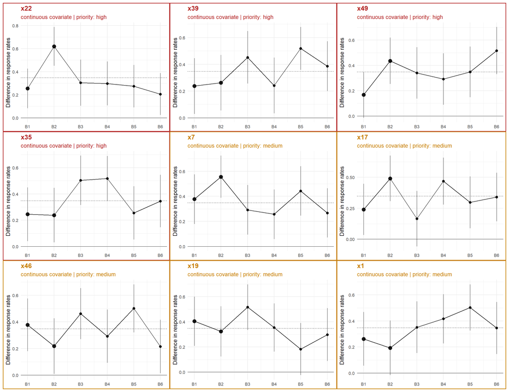

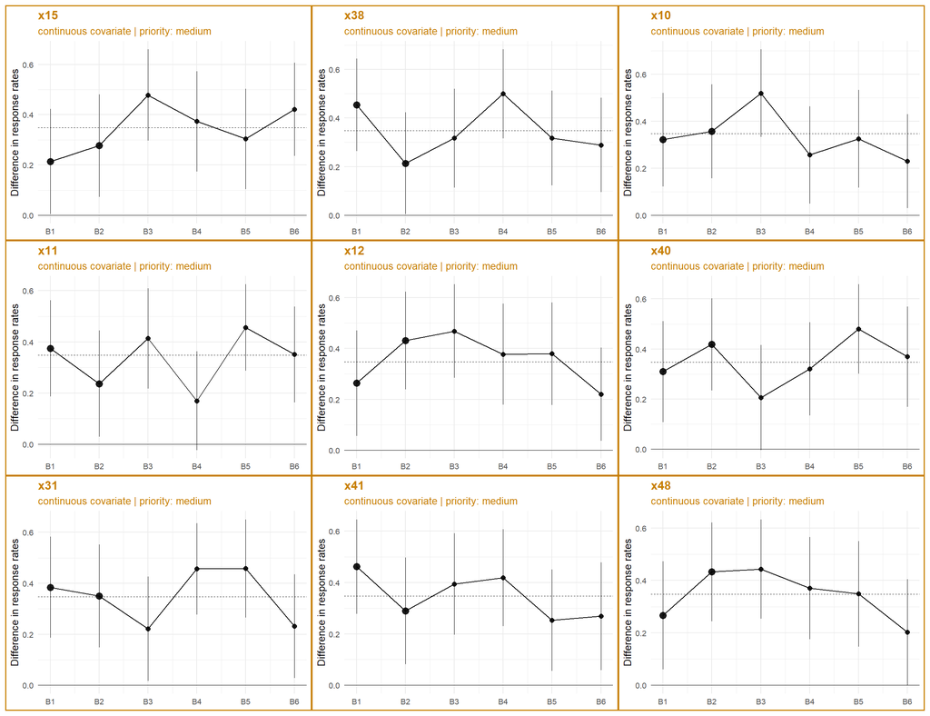

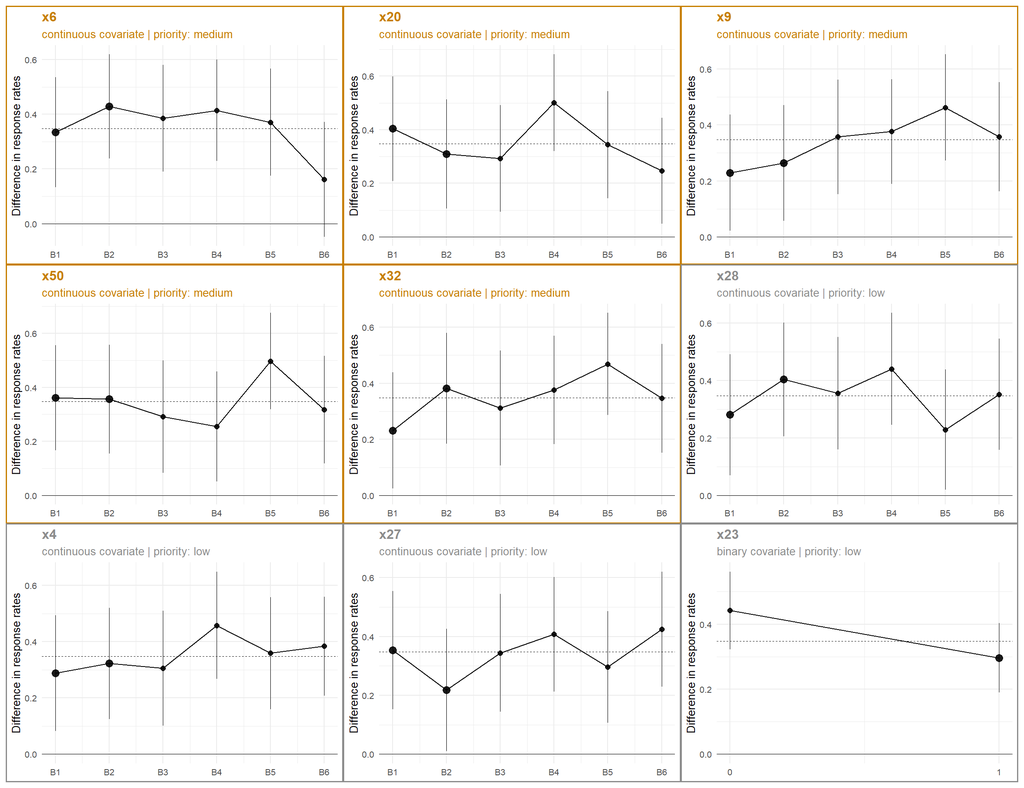

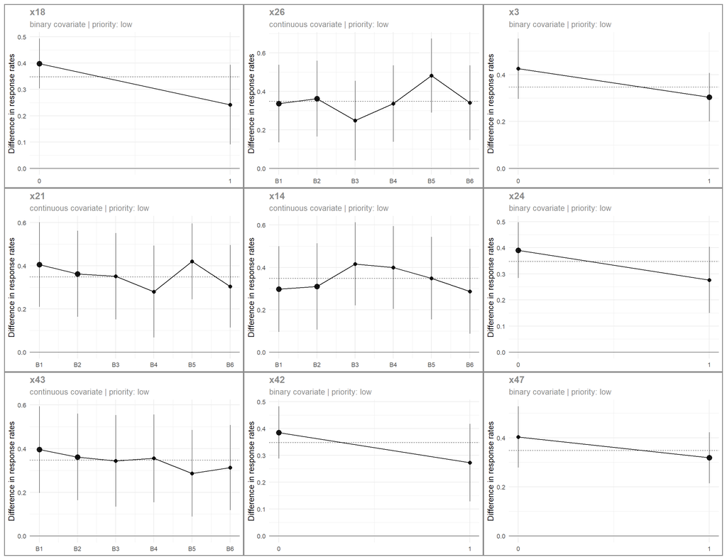

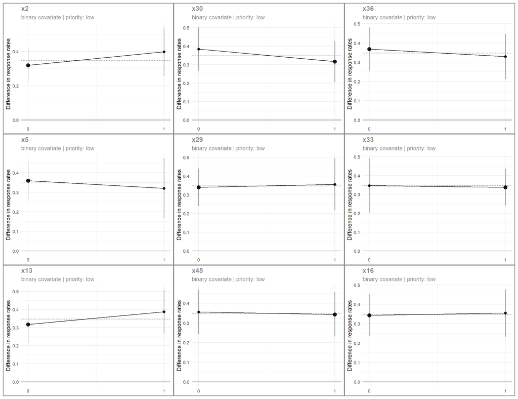

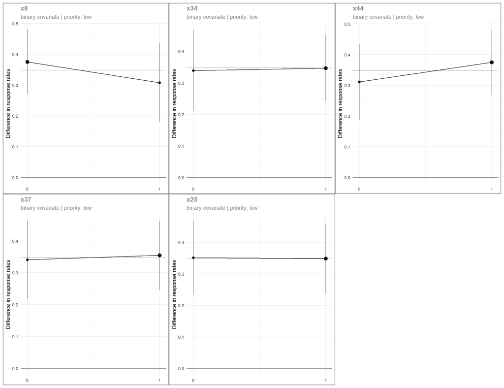

## Dataset 7499

All variables are shown. Numeric prioritisation is used only to order and colour the plots for faster visual review.

| dataset_id | endpoint | n_obs | n_vars | n_bins | overall_effect |
| --- | --- | --- | --- | --- | --- |
| 7499 | binary | 150 | 15 | 4 | 0.12 |

### Dataset priority overview

| n_high | n_medium | n_low | prop_high | prop_medium_or_higher | max_priority_score | mean_priority_score | top_priority_vars | dataset_priority_hint |
| --- | --- | --- | --- | --- | --- | --- | --- | --- |
| 4 | 5 | 6 | 0.267 | 0.6 | 1.02 | 0.542 | x8, x7, x12, x15, x1 | multiple_high_priority_signals |

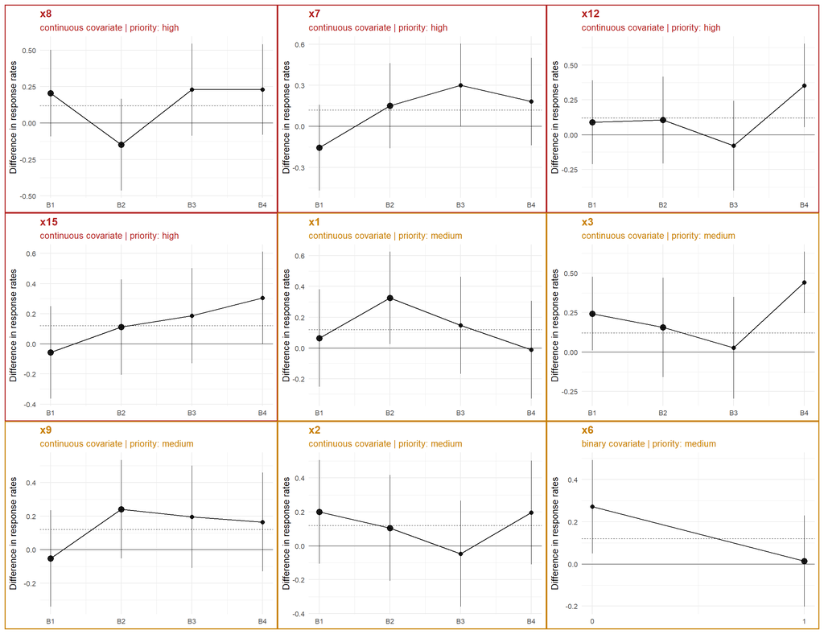

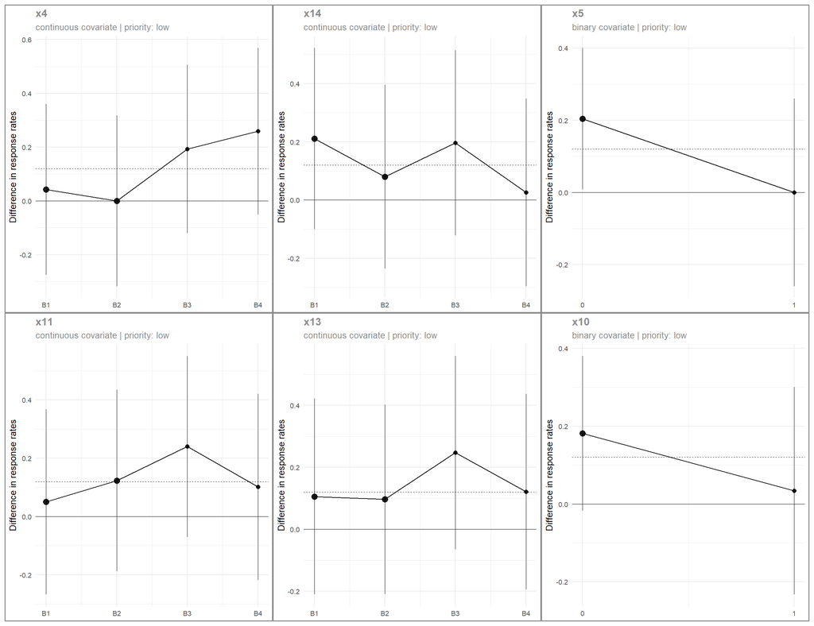

## Dataset 7619

All variables are shown. Numeric prioritisation is used only to order and colour the plots for faster visual review.

| dataset_id | endpoint | n_obs | n_vars | n_bins | overall_effect |
| --- | --- | --- | --- | --- | --- |
| 7619 | binary | 150 | 50 | 4 | 0.293 |

### Dataset priority overview

| n_high | n_medium | n_low | prop_high | prop_medium_or_higher | max_priority_score | mean_priority_score | top_priority_vars | dataset_priority_hint |
| --- | --- | --- | --- | --- | --- | --- | --- | --- |
| 3 | 21 | 26 | 0.06 | 0.48 | 1.023 | 0.43 | x22, x21, x18, x29, x34 | multiple_high_priority_signals |

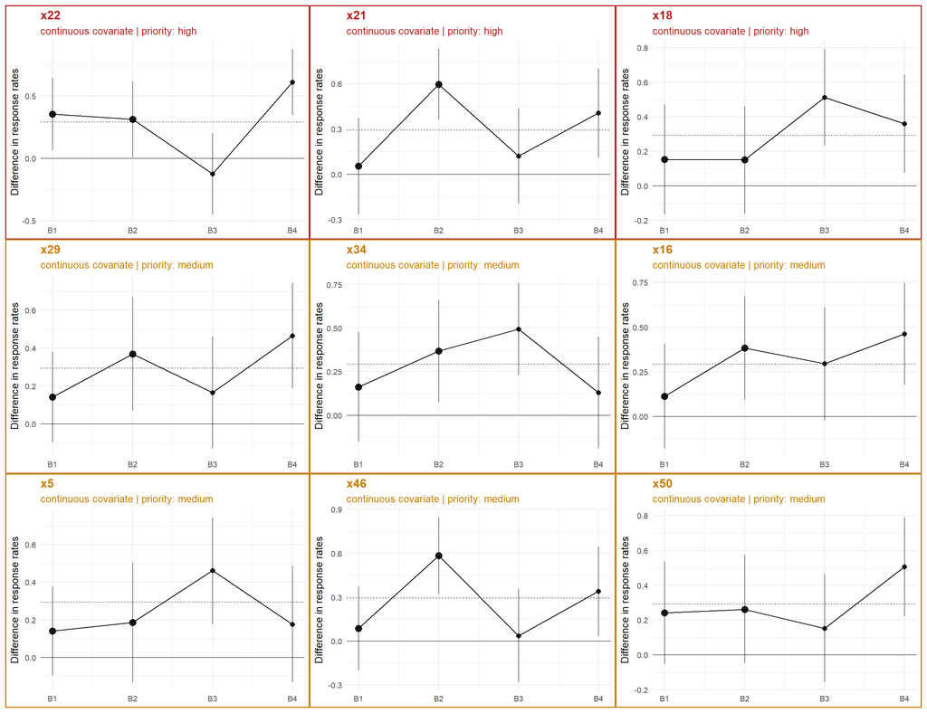

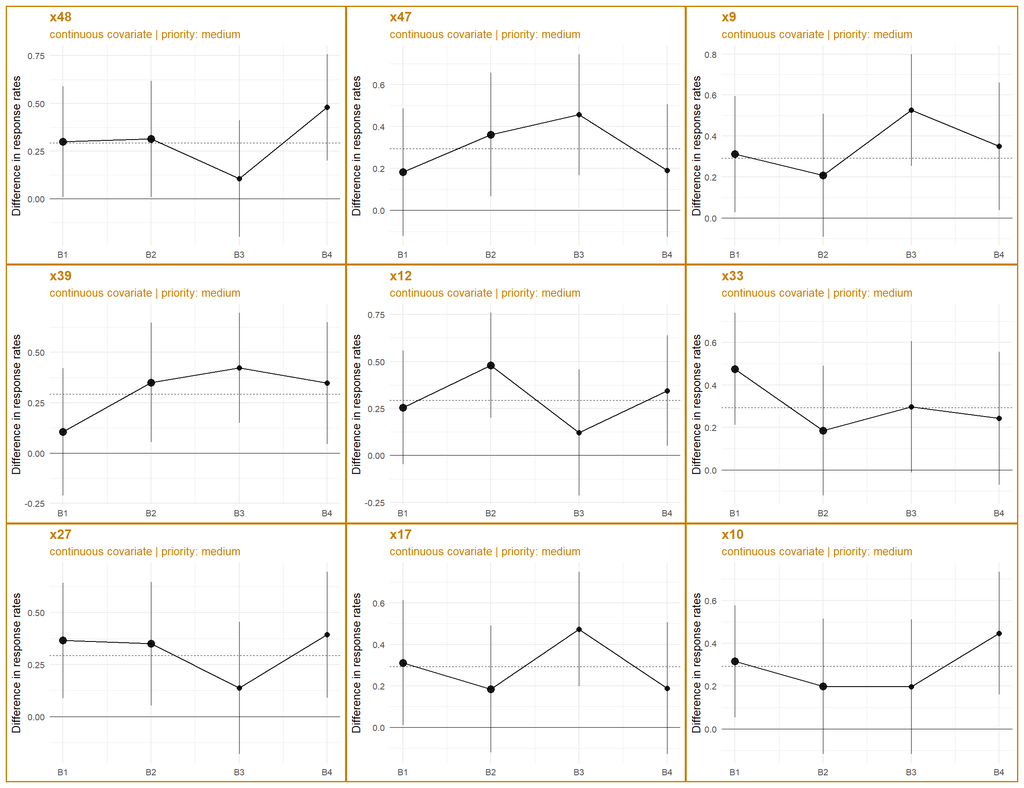

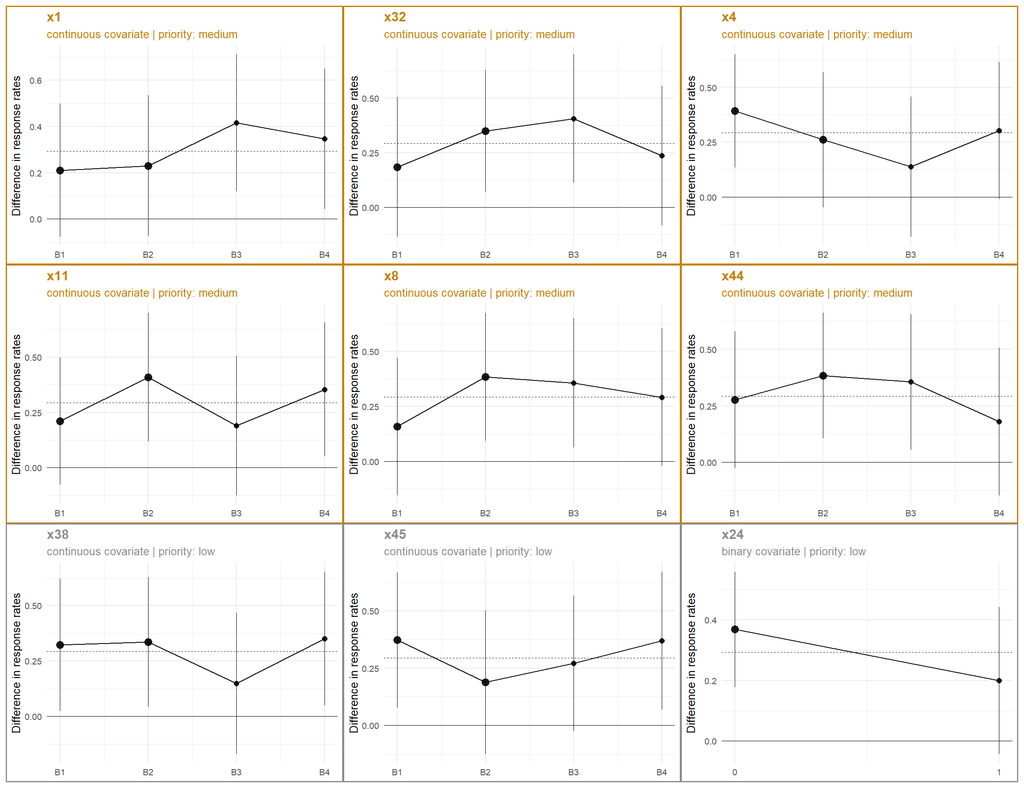

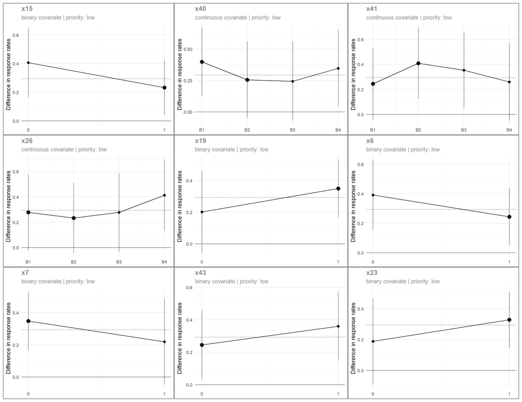

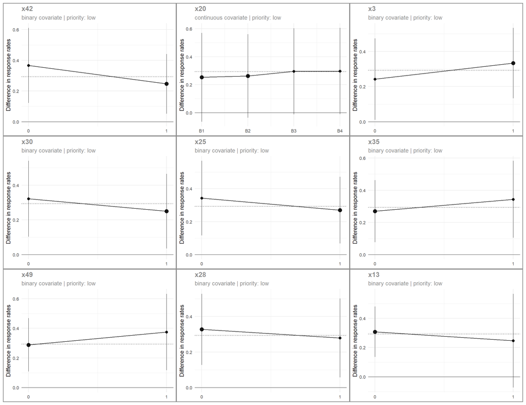

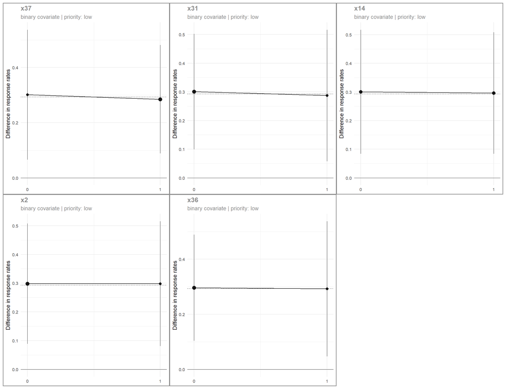

## Dataset 7756

All variables are shown. Numeric prioritisation is used only to order and colour the plots for faster visual review.

| dataset_id | endpoint | n_obs | n_vars | n_bins | overall_effect |
| --- | --- | --- | --- | --- | --- |
| 7756 | binary | 150 | 6 | 4 | 0.053 |

### Dataset priority overview

| n_high | n_medium | n_low | prop_high | prop_medium_or_higher | max_priority_score | mean_priority_score | top_priority_vars | dataset_priority_hint |
| --- | --- | --- | --- | --- | --- | --- | --- | --- |
| 2 | 3 | 1 | 0.333 | 0.833 | 1.055 | 0.675 | x2, x5, x1, x4, x6 | high_plus_additional_support |

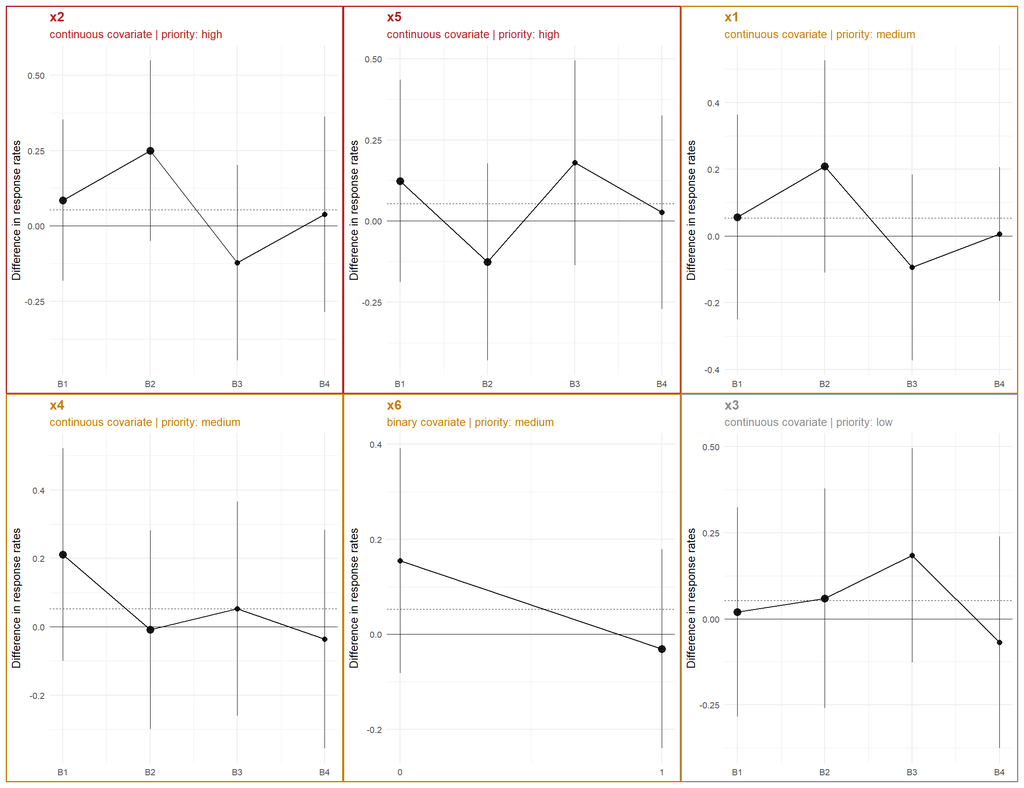

## Dataset 9129

All variables are shown. Numeric prioritisation is used only to order and colour the plots for faster visual review.

| dataset_id | endpoint | n_obs | n_vars | n_bins | overall_effect |
| --- | --- | --- | --- | --- | --- |
| 9129 | continuous | 150 | 6 | 4 | -0.233 |

### Dataset priority overview

| n_high | n_medium | n_low | prop_high | prop_medium_or_higher | max_priority_score | mean_priority_score | top_priority_vars | dataset_priority_hint |
| --- | --- | --- | --- | --- | --- | --- | --- | --- |
| 3 | 2 | 1 | 0.5 | 0.833 | 0.965 | 0.675 | x3, x1, x6, x4, x2 | multiple_high_priority_signals |

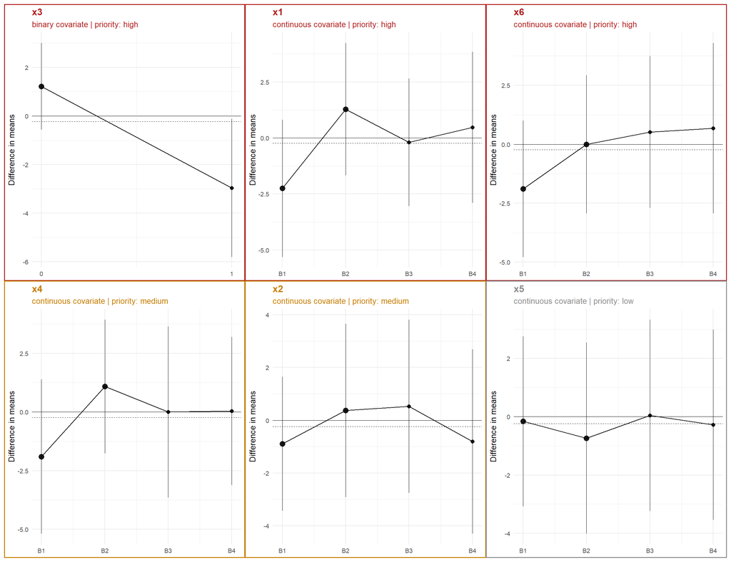

## Dataset 9371

All variables are shown. Numeric prioritisation is used only to order and colour the plots for faster visual review.

| dataset_id | endpoint | n_obs | n_vars | n_bins | overall_effect |
| --- | --- | --- | --- | --- | --- |
| 9371 | continuous | 700 | 6 | 8 | 0.558 |

### Dataset priority overview

| n_high | n_medium | n_low | prop_high | prop_medium_or_higher | max_priority_score | mean_priority_score | top_priority_vars | dataset_priority_hint |
| --- | --- | --- | --- | --- | --- | --- | --- | --- |
| 3 | 2 | 1 | 0.5 | 0.833 | 1.1 | 0.633 | x5, x3, x1, x6, x2 | multiple_high_priority_signals |

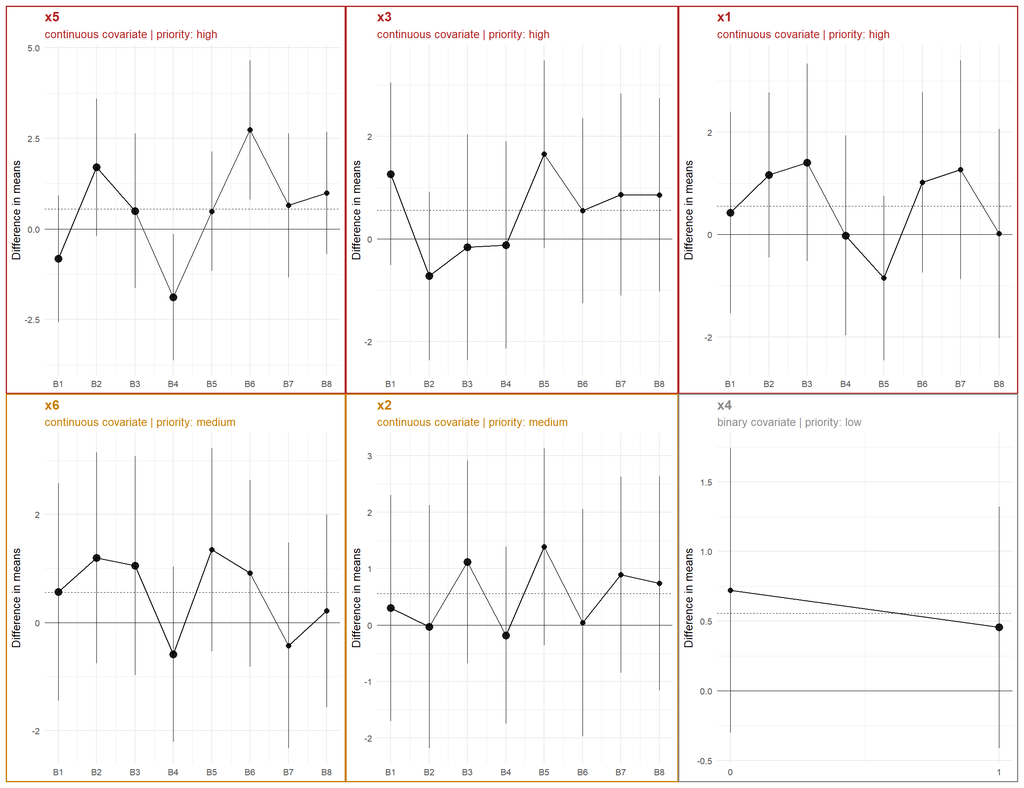

## Dataset 9503

All variables are shown. Numeric prioritisation is used only to order and colour the plots for faster visual review.

| dataset_id | endpoint | n_obs | n_vars | n_bins | overall_effect |
| --- | --- | --- | --- | --- | --- |
| 9503 | continuous | 700 | 50 | 8 | -0.472 |

### Dataset priority overview

| n_high | n_medium | n_low | prop_high | prop_medium_or_higher | max_priority_score | mean_priority_score | top_priority_vars | dataset_priority_hint |
| --- | --- | --- | --- | --- | --- | --- | --- | --- |
| 21 | 10 | 19 | 0.42 | 0.62 | 1.08 | 0.575 | x5, x9, x15, x2, x44 | multiple_high_priority_signals |

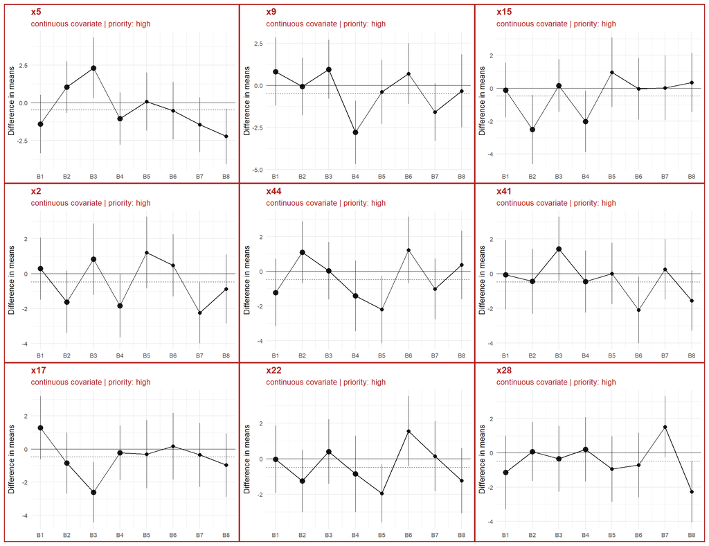

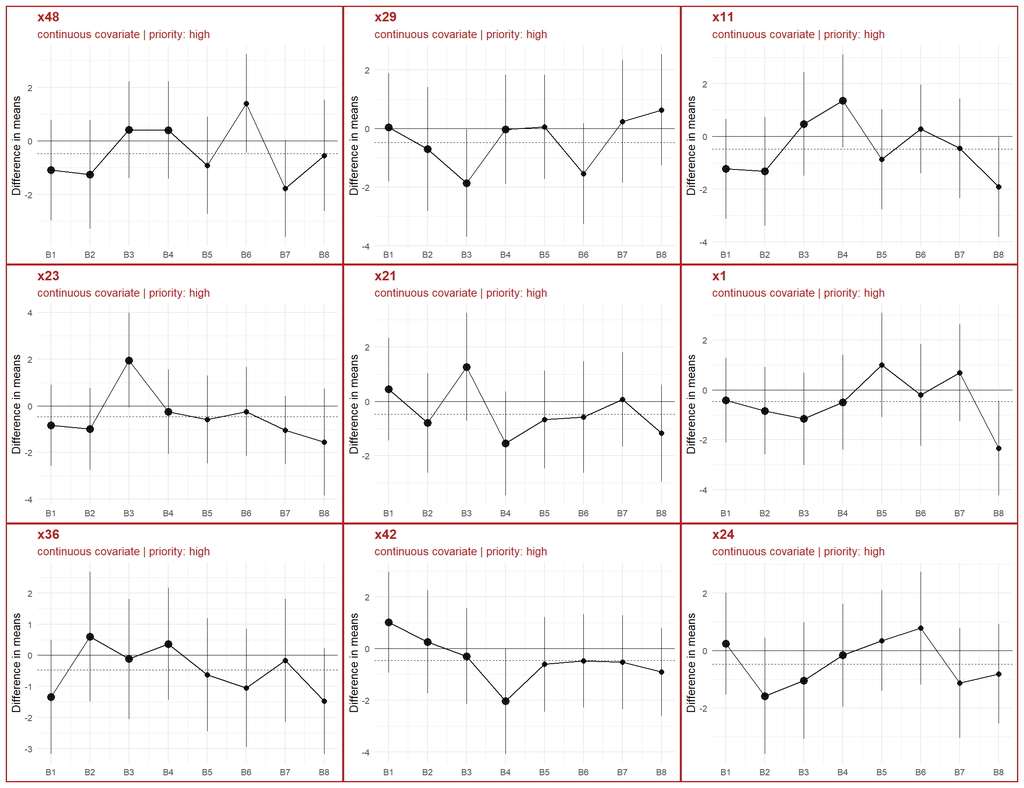

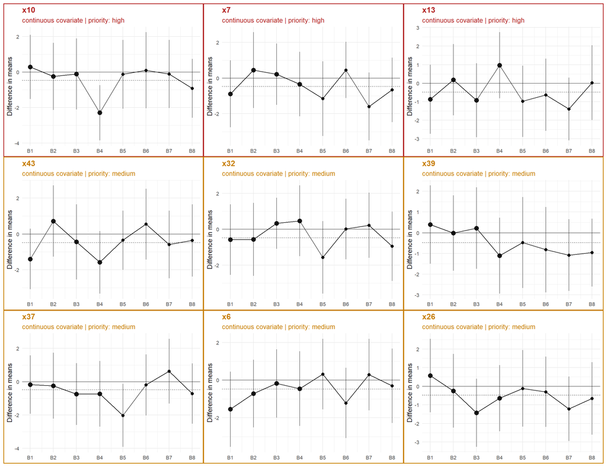

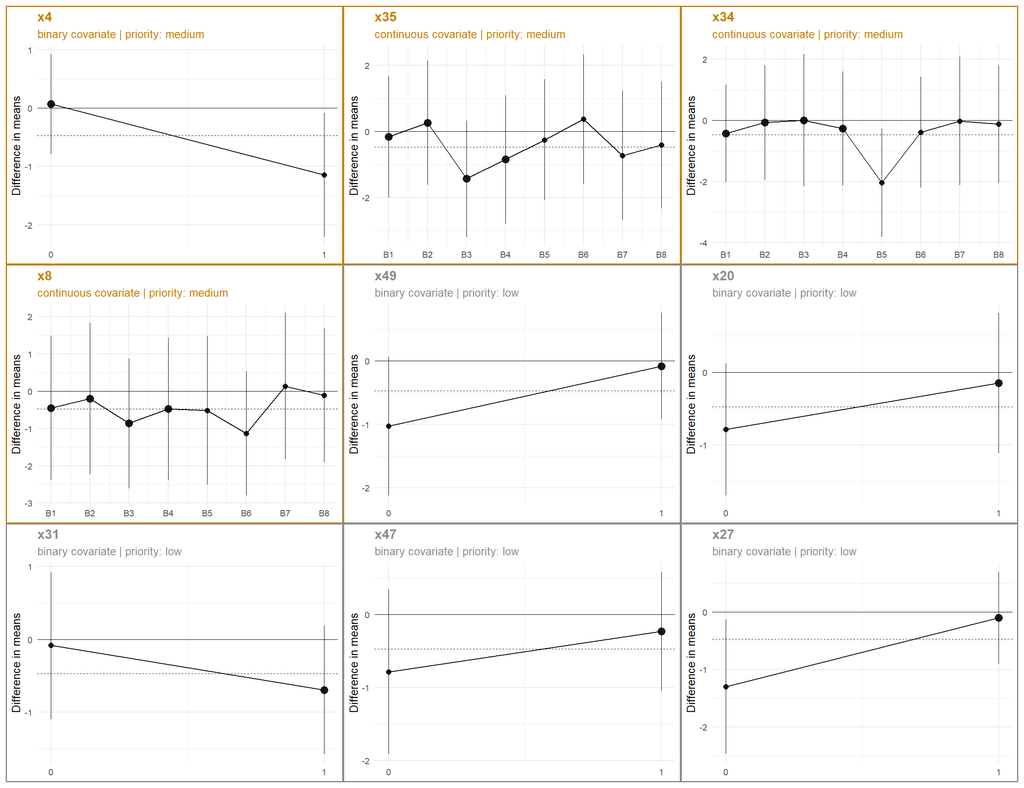

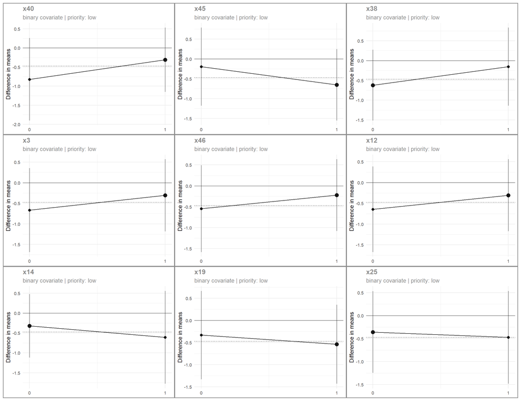

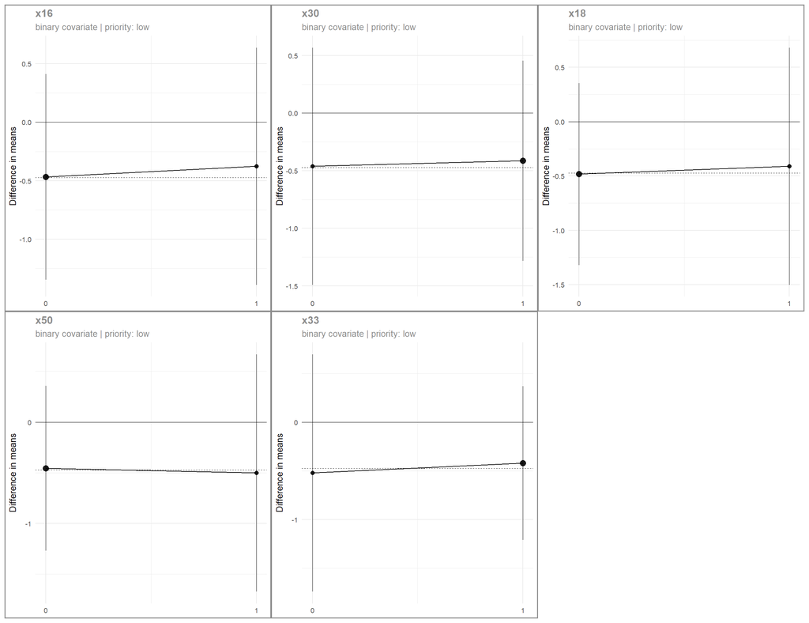

## Dataset 9563

All variables are shown. Numeric prioritisation is used only to order and colour the plots for faster visual review.

| dataset_id | endpoint | n_obs | n_vars | n_bins | overall_effect |
| --- | --- | --- | --- | --- | --- |
| 9563 | binary | 150 | 6 | 4 | 0.08 |

### Dataset priority overview

| n_high | n_medium | n_low | prop_high | prop_medium_or_higher | max_priority_score | mean_priority_score | top_priority_vars | dataset_priority_hint |
| --- | --- | --- | --- | --- | --- | --- | --- | --- |
| 4 | 0 | 2 | 0.667 | 0.667 | 0.855 | 0.592 | x4, x6, x2, x1, x3 | multiple_high_priority_signals |

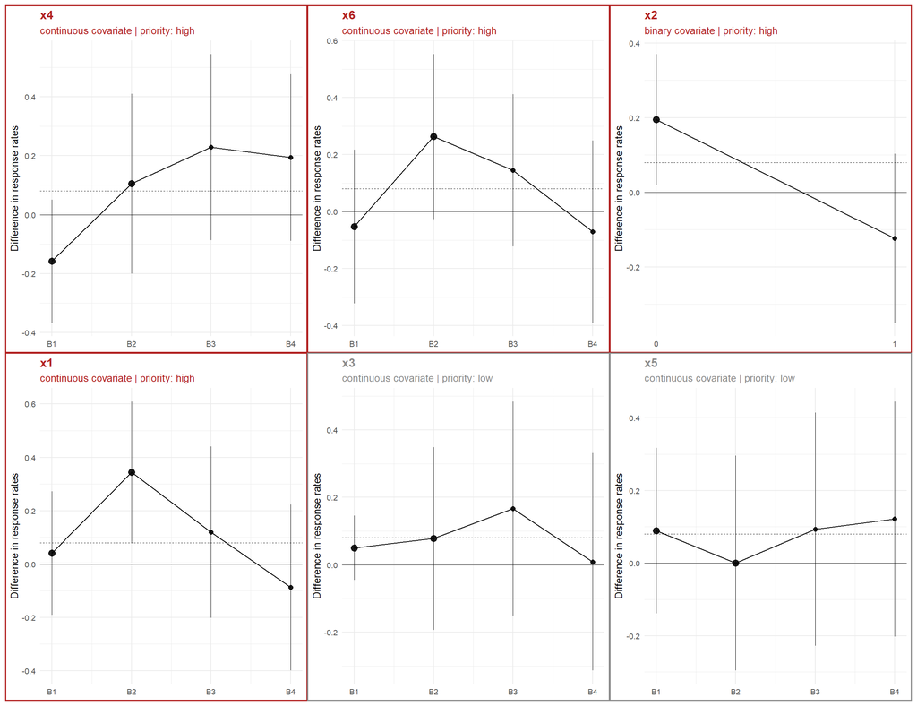

## Dataset 9779

All variables are shown. Numeric prioritisation is used only to order and colour the plots for faster visual review.

| dataset_id | endpoint | n_obs | n_vars | n_bins | overall_effect |
| --- | --- | --- | --- | --- | --- |
| 9779 | binary | 150 | 6 | 4 | 0.253 |

### Dataset priority overview

| n_high | n_medium | n_low | prop_high | prop_medium_or_higher | max_priority_score | mean_priority_score | top_priority_vars | dataset_priority_hint |
| --- | --- | --- | --- | --- | --- | --- | --- | --- |
| 1 | 2 | 3 | 0.167 | 0.5 | 1.085 | 0.467 | x6, x4, x2, x3, x5 | high_plus_additional_support |

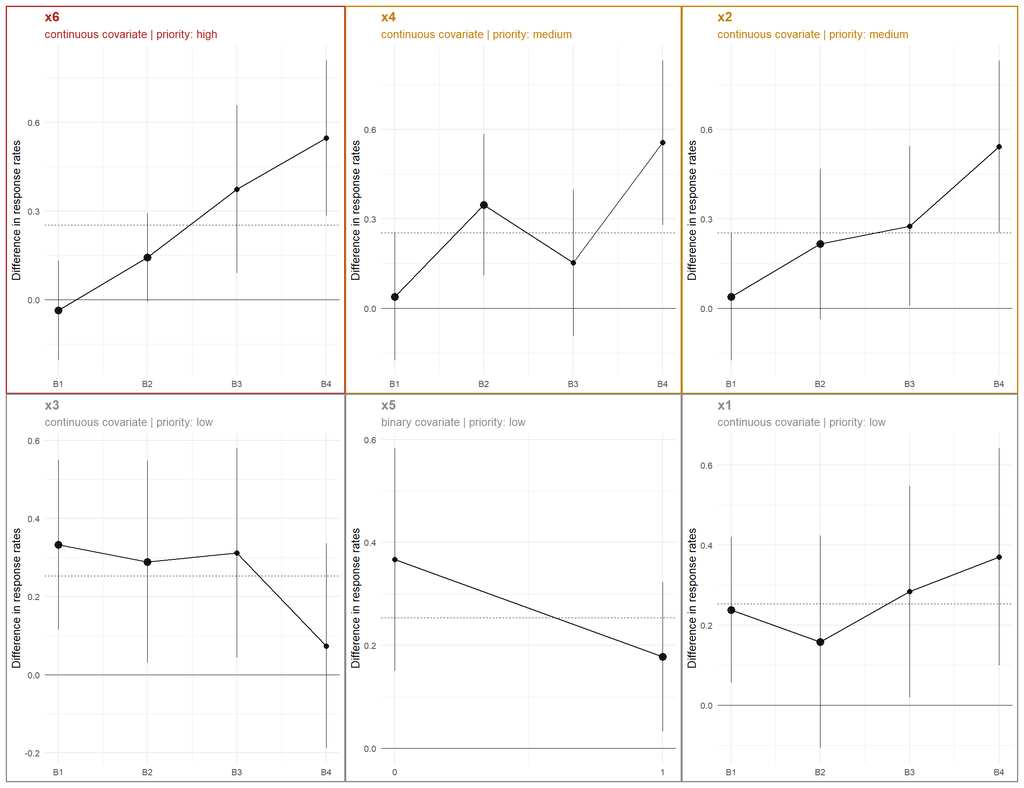